# HarvestLite Explorations

Nelson Stauffer

## Introduction

Spatial configuration is important to consider when dealing with landscapes because every agent and entity, biotic or abiotic, has to physically pass through space.

The HarvestLite software runs a spatial model approximating the effects of a probabilistic logging effort over time within a discrete area. There are both model parameters (mean harvest size in hectares, percent of forest cut each decade, spatial configuration of harvest, and model seed number) and reporting parameters (buffer width and opening persistence) available to the user. Model parameters affect the model run and result in differences in the model output. Reporting parameters do not have an effect on the model output, but do result in differences in the calculations of values reported from the output.

Of the reported values, those of greatest interest are area of area of interior habitat, area of edge habitat, and mean patch size. Interior habitat is the area within a patch which is far enough from the edge of the patch to be considered free (as defined by the user) from edge effects. Edge habitat is the area within a patch that is close enough to the interface with other patch types to have edge effects resulting from interactions at the boundaries (again, as defined by the user). These two values are affected by changes in patch size and the distance the user defines as “edge,” so it is of interest how parameters which drive those, i.e. every model parameter and reporting parameter, would in turn affect the interior and edge habitat areas.

Mean patch size, like habitat areas, will vary with all parameters, but of particular interest here is how the distribution of the harvesting efforts, either dispersed or clumped, will result in changes to intact patch sizes.

## Methods

### Defaults

HarvestLite takes as its starting data source a raster .gis file in which each cell is assigned a value representing the age of the forest stand in the cell in decades. The software comes with two data sets and this work used the “undisturbed” data, UNDISTBD.GIS. Additionally, every time the model is executed, the user can assign a seed number or allow the software to use a random one. The seed number used for every model run here was 4 to ensure that differences in output were not due to differences in random effects but instead differences in parameters.

### Model Runs

For each parameter being investigated, multiple runs were executed with a different value for the parameter in each run. Only one parameter was changed from the default value in a run so that the effects observed would be isolated to the results of that parameter.

The following values were used for each of the parameters, default in bold:

- Mean harvest size (ha): 2.5, 7.5, **5.0**, 10.0, 12.5
- Forest area cut (%/decade): 0.5, **1.0**, 2.5, 5.0, 7.5
- Spatial configuration of harvest: **“Dispersed”**, “Clumped”
- Buffer width (m): 30, 60, 120, **180**, 240
- Opening persistence (decades): 1, **2**, 3, 4, 5

After a model run, the software was used to report both patch and habitat metrics. The resulting rasters and log files were saved to be parsed into usable data for analysis.

## Results

### Mean Harvest Size

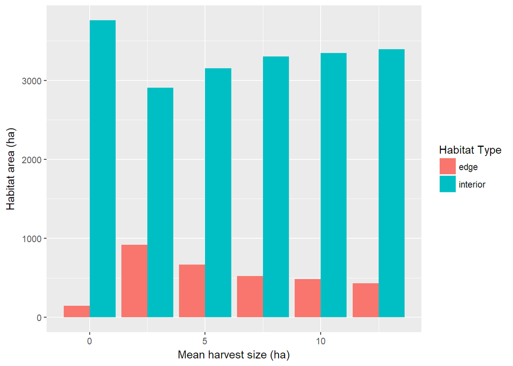

### Percent of Forest Cut Each Decade

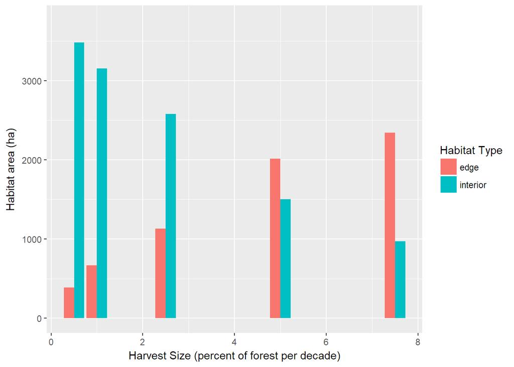

### Spatial Configuration

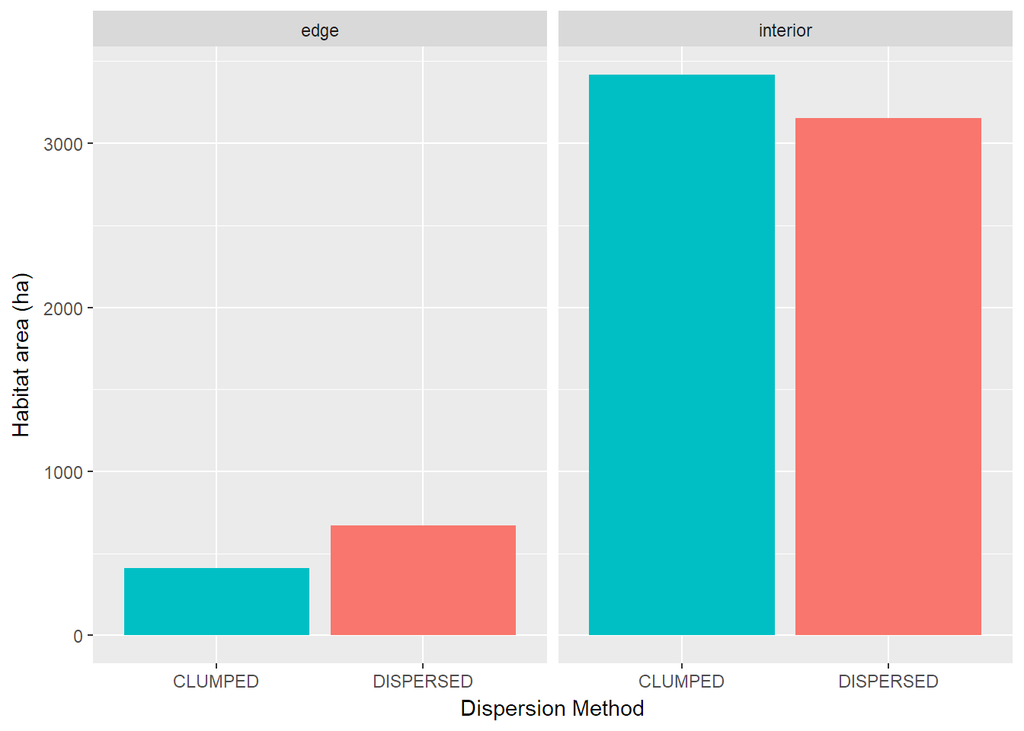

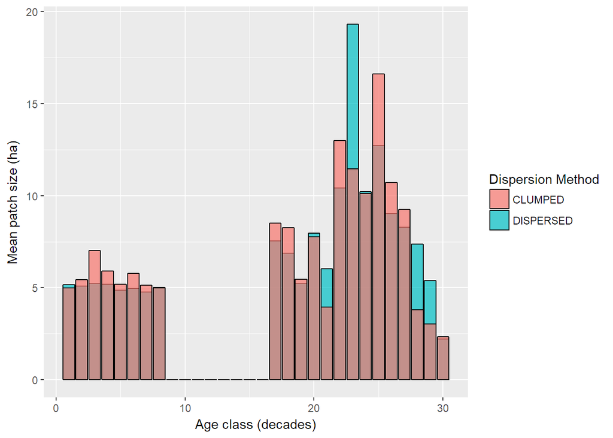

### Buffer Width

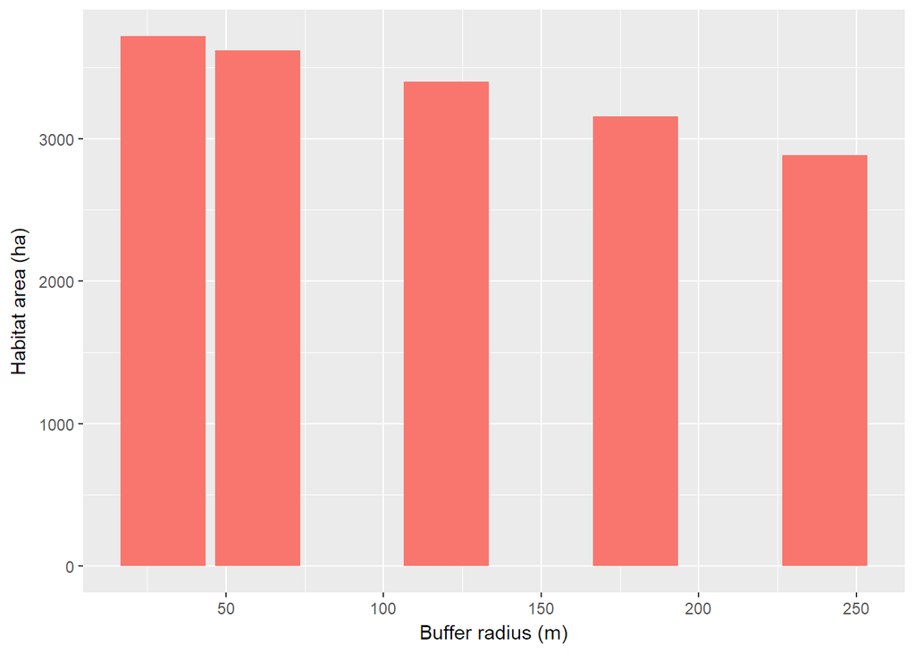

### Persistence Time

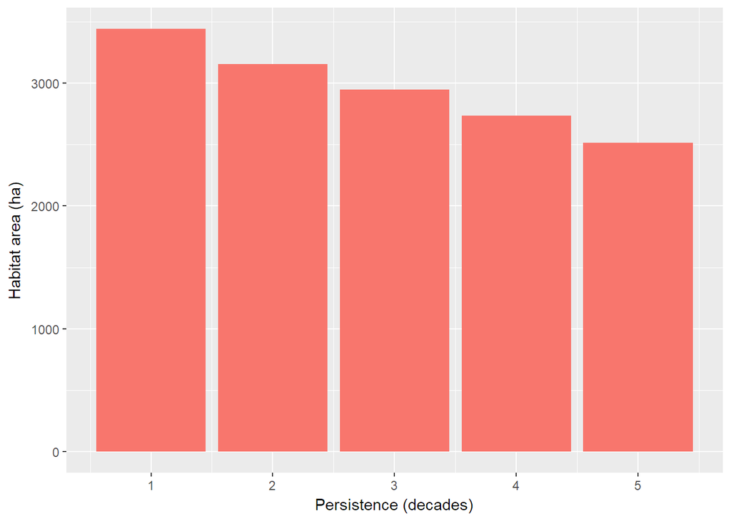